# Exam 1

## Exam 1

#### Metainformation

1. | Tag | Value |
   | --- | --- |
   | `file` | Inferential_Statistics_vufsw-criticalvalue-0189-nl_vufsw-criticalvalue-0189-nl |
   | `name` | vufsw-criticalvalue-0189-nl |
   | `section` | inferential statistics/nhst/significance level/critical value |
   | `type` | schoice |
   | `solution` | FALSE, TRUE, FALSE, FALSE |
   | `ID` | e866d |
   | `Type` | test choice |
   | `Program` | NA |
   | `Language` | Dutch |
   | `Level` | statistical reasoning |

#### Question

   Uit een onderzoek onder een representatieve steekproef van 2141 Nederlanders (n=2141) van I&O Research naar het draagvlak van het coronabeleid blijkt dat 45% van de respondenten wil dat de maatregelen versoepeld worden (zie nieuwsbericht hierover hieronder).

   Stel, een politiek commentator beweert dat hij denkt dat meer dan de helft (50%) van de Nederlanders wil dat de maatregelen versoepeld worden.

   Toets deze hypothese van de commentator met behulp van de bovenstaande steekproefgegevens. Hanteer een significantieniveau van 1% (α = 0,01). Welke **kritieke** test-statistic moeten we bij deze toets gebruiken?

   (*bron*: nos.nl, 17 februari 2021)

[figure not shown]

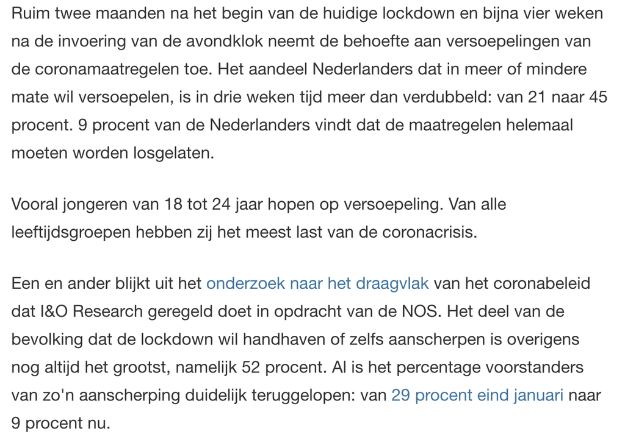

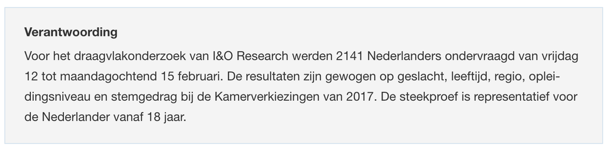

   1. **FALSE:** We gebruiken een kritieke **t-waarde**. Dat is bij deze toetsing 2.36.
   2. **TRUE:** We gebruiken een kritieke **z-score**. Dat is bij deze toetsing 2.33.
   3. **FALSE:** We gebruiken een kritieke **z-score**. Dat is bij deze toetsing 1.28.
   4. **FALSE:** We gebruiken een kritieke **t-waarde**. Dat is bij deze toetsing 3.17.

#### Solution

   Language  
   Nederlands

   Levels of Difficulty  
   Easy

   M&T Basics of quantitative research  
   Basics of quantitative research

   M&T BIS  
   Default value
   1. False
   2. True
   3. False
   4. False